# ch11-12.rmd

Brea Koenes

10/24/2022

# Chapter 11

## 2

There is no indicator for the Ford category because it is the intercept.

A car’s miles per gallon in a city given its a Subaru

a Ford’s miles per gallon in a city

## 10

```r
penguin_data <- penguins_bayes |>
  filter(species %in% c("Adelie", "Gentoo"))

summary(penguin_data)
```

```
##       species          island         year      bill_length_mm  bill_depth_mm
##  Adelie   :152   Biscoe   :168   Min.   :2007   Min.   :32.10   Min.   :13.10
##  Chinstrap:  0   Dream    : 56   1st Qu.:2007   1st Qu.:38.35   1st Qu.:15.00
##  Gentoo   :124   Torgersen: 52   Median :2008   Median :42.00   Median :17.00
##                                  Mean   :2008   Mean   :42.70   Mean   :16.84
##                                  3rd Qu.:2009   3rd Qu.:46.67   3rd Qu.:18.50
##                                  Max.   :2009   Max.   :59.60   Max.   :21.50
##                                                 NA's   :2       NA's   :2
##  flipper_length_mm  body_mass_g   above_average_weight     sex
##  Min.   :172.0     Min.   :2850   0   :132             female:131
##  1st Qu.:190.0     1st Qu.:3600   1   :142             male  :134
##  Median :198.0     Median :4262   NA's:  2             NA's  : 11
##  Mean   :202.2     Mean   :4318
##  3rd Qu.:215.0     3rd Qu.:4950
##  Max.   :231.0     Max.   :6300
##  NA's   :2         NA's   :2
```

```r
require(rstanarm)

model <- stan_glm(
  body_mass_g ~ species + flipper_length_mm, data = penguin_data,
  family = gaussian,
  prior_PD = TRUE,
  prior_intercept = normal(42.7, 10, autoscale = TRUE),
  prior = normal(4318, 1700, autoscale = TRUE),
  prior_aux = exponential(1, autoscale = TRUE),
  chains = 5, iter = 8000, seed = 84735)
summary(model)
```

```
##
## Model Info:
##  function:     stan_glm
##  family:       gaussian [identity]
##  formula:      body_mass_g ~ species + flipper_length_mm
##  algorithm:    sampling
##  sample:       20000 (posterior sample size)
##  priors:       see help('prior_summary')
##  observations: 274
##  predictors:   3
##
## Estimates:
##                     mean        sd          10%         50%         90%
## (Intercept)         -808256.1  19147552.8 -25549630.2   -802652.2  23552588.5
## speciesGentoo         64953.7   2839937.7  -3589437.2     71000.9   3658254.1
## flipper_length_mm      3853.6     94532.8   -116242.2      3370.4    125833.9
## sigma                   829.9       834.7        88.6       573.8      1908.2
##
## MCMC diagnostics
##                   mcse     Rhat     n_eff
## (Intercept)       135520.1      1.0 19963
## speciesGentoo      19940.4      1.0 20284
## flipper_length_mm    669.3      1.0 19947
## sigma                  5.7      1.0 21570
## log-posterior          0.0      1.0  7780
##
## For each parameter, mcse is Monte Carlo standard error, n_eff is a crude measure of effective sample size, and Rhat is the potential scale reduction factor on split chains (at convergence Rhat=1).
```

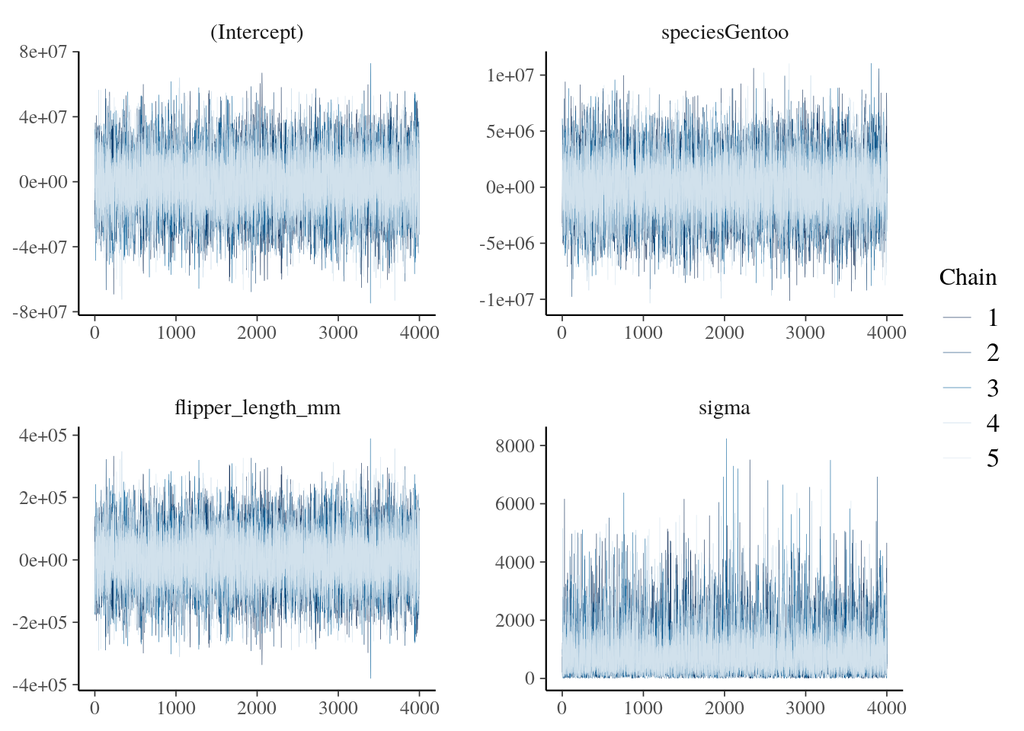

```r
# Trace plots of parallel chains
mcmc_trace(model, size = .1)
```

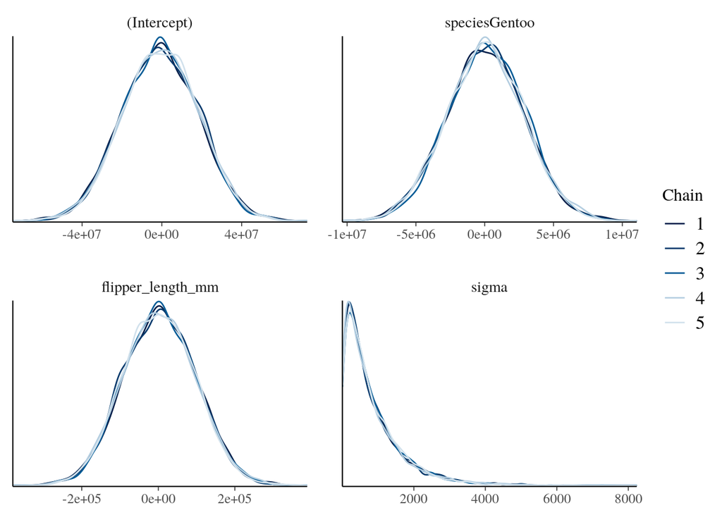

```r
# Density plots of parallel chains
mcmc_dens_overlay(model)
```

```r
tidy(model, effects = c("fixed", "aux"),
     conf.int = TRUE, conf.level = 0.95)
```

```
## # A tibble: 4 × 5
##   term              estimate std.error    conf.low conf.high
##   <chr>                <dbl>     <dbl>       <dbl>     <dbl>
## 1 (Intercept)       -802652. 19404177. -38008171.  36004255.
## 2 speciesGentoo       71001.  2846624.  -5523409.   5669937.
## 3 flipper_length_mm    3370.    96013.   -177649.    187301.
## 4 sigma                 574.      835.        22.5     3086.
```

```r
model2 <- update(model, prior_PD = FALSE)
```

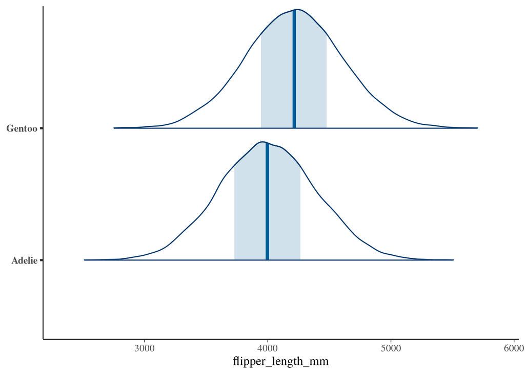

```r
# Simulate a set of predictions
set.seed(84735)
model2_predict <- posterior_predict(
  model2,
  newdata = data.frame(species = c("Adelie", "Gentoo"),
                       flipper_length_mm = 197))

# Plot the posterior predictive models
mcmc_areas(model2_predict) +
  ggplot2::scale_y_discrete(labels = c("Adelie", "Gentoo")) +
  xlab("flipper_length_mm")
```

## 11

```r
interaction_model <- stan_glm(
  body_mass_g ~ species + flipper_length_mm + species:flipper_length_mm, data = penguin_data,
  family = gaussian,
  prior_intercept = normal(42.7, 10, autoscale = TRUE),
  prior = normal(4318, 1700, autoscale = TRUE),
  prior_aux = exponential(1, autoscale = TRUE),
  chains = 4, iter = 10000*4, seed = 84735)
# Posterior summary statistics
tidy(interaction_model, effects = c("fixed", "aux"))
```

```
## # A tibble: 6 × 3
##   term                            estimate std.error
##   <chr>                              <dbl>     <dbl>
## 1 (Intercept)                      -2534.     921.
## 2 speciesGentoo                    -4252.    1496.
## 3 flipper_length_mm                   32.8      4.85
## 4 speciesGentoo:flipper_length_mm     21.8      7.27
## 5 sigma                              387.      16.8
## 6 mean_PPD                          4318.      33.3
```

[figure not shown]

```r
set.seed(84735)
penguin_data |> na.omit() |>
  add_fitted_draws(interaction_model, n = 50) |>
  ggplot(aes(x = "Adelie", y = "Gentoo", color = flipper_length_mm)) +
    geom_line(aes(y = .value, group = paste(species, .draw)))
```

```r
tidy(interaction_model, effects = c("fixed", "aux"))
```

```
## # A tibble: 6 × 3
##   term                            estimate std.error
##   <chr>                              <dbl>     <dbl>
## 1 (Intercept)                      -2534.     921.
## 2 speciesGentoo                    -4252.    1496.
## 3 flipper_length_mm                   32.8      4.85
## 4 speciesGentoo:flipper_length_mm     21.8      7.27
## 5 sigma                              387.      16.8
## 6 mean_PPD                          4318.      33.3
```

## 12

```r
three_predictor_model <- stan_glm(
  body_mass_g ~ flipper_length_mm + bill_depth_mm + bill_length_mm, data = penguin_data,
  family = gaussian,
  prior_intercept = normal(42.7, 10, autoscale = TRUE),
  prior = normal(4318, 1700, autoscale = TRUE),
  prior_aux = exponential(1, autoscale = TRUE),
  chains = 4, iter = 10000*4, seed = 84735)
posterior_interval(three_predictor_model, prob = 0.95)
```

```
##                          2.5%       97.5%
## (Intercept)       -7231.67756 -5068.76753
## flipper_length_mm    26.37794    38.10409
## bill_depth_mm        28.08234    80.42888
## bill_length_mm       55.91879    87.06711
## sigma               312.52710   369.81537
```

All predictors have a significant positive association with body mass.

## 13

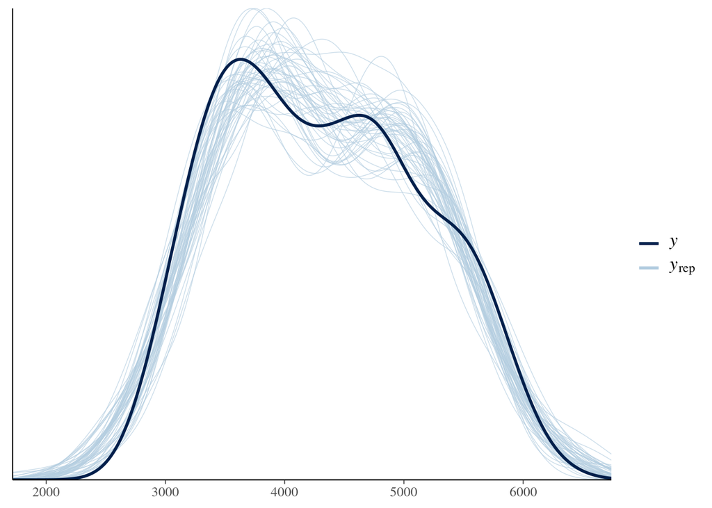

```r
mod1 <- stan_glm(
  body_mass_g ~ flipper_length_mm, data = penguin_data,
  family = gaussian,
  prior_intercept = normal(42.7, 10, autoscale = TRUE),
  prior = normal(4318, 1700, autoscale = TRUE),
  prior_aux = exponential(1, autoscale = TRUE),
  chains = 3, iter = 5000*3, seed = 84735)
mod2 <- stan_glm(
  body_mass_g ~ species, data = penguin_data,
  family = gaussian,
  prior_intercept = normal(42.7, 10, autoscale = TRUE),
  prior = normal(4318, 1700, autoscale = TRUE),
  prior_aux = exponential(1, autoscale = TRUE),
  chains = 3, iter = 5000*3, seed = 84735)
mod3 <- stan_glm(
  body_mass_g ~ flipper_length_mm + species, data = penguin_data,
  family = gaussian,
  prior_intercept = normal(42.7, 10, autoscale = TRUE),
  prior = normal(4318, 1700, autoscale = TRUE),
  prior_aux = exponential(1, autoscale = TRUE),
  chains = 3, iter = 5000*3, seed = 84735)
mod4 <- stan_glm(
  body_mass_g ~ flipper_length_mm + bill_length_mm + bill_depth_mm,
  data = penguin_data,
  family = gaussian,
  prior_intercept = normal(42.7, 10, autoscale = TRUE),
  prior = normal(4318, 1700, autoscale = TRUE),
  prior_aux = exponential(1, autoscale = TRUE),
  chains = 3, iter = 5000*3, seed = 84735)
pp_check(mod1)
```

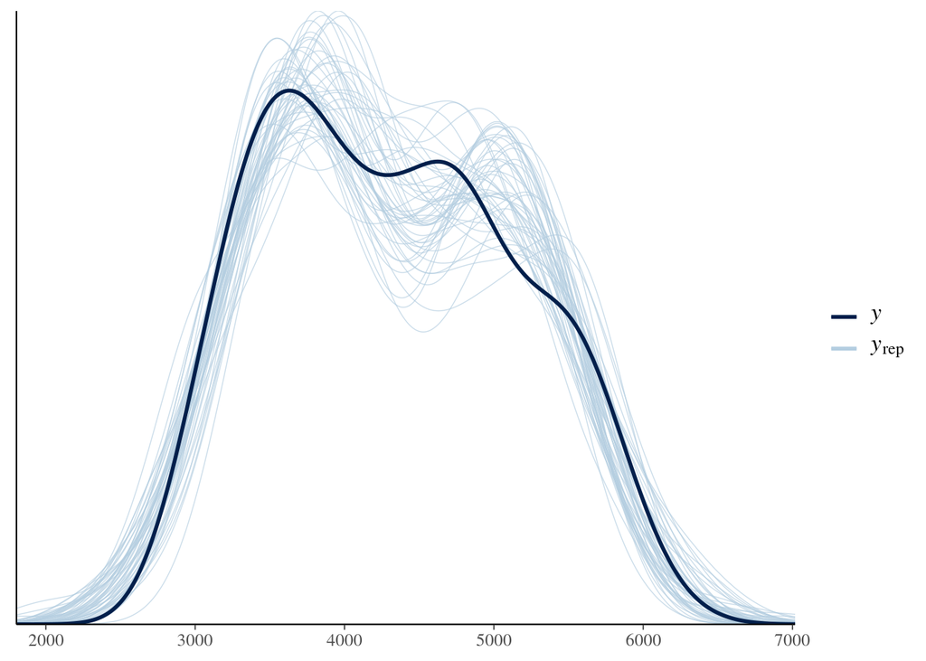

```r
pp_check(mod2)
```

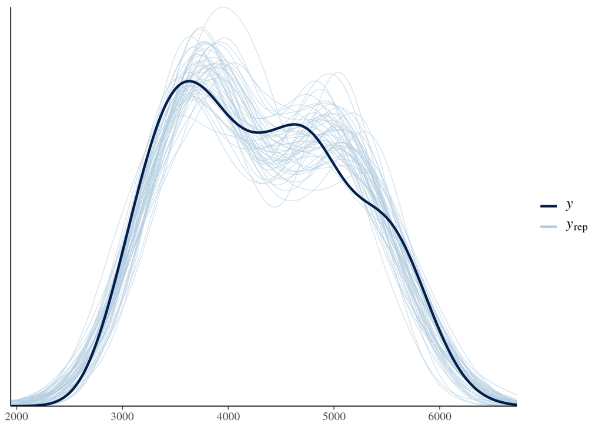

```r
pp_check(mod3)
```

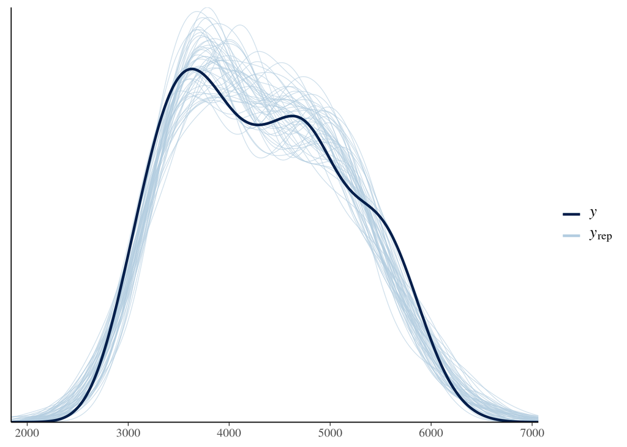

```r
pp_check(mod4)
```

```r
penguins_complete <- penguin_data |>
  select(flipper_length_mm, body_mass_g, species,
         bill_length_mm, bill_depth_mm) |>
  na.omit()
```

```r
set.seed(84735)
prediction_summary_cv(model = mod1, data = penguins_complete, k = 10)
```

```
## $folds
##    fold      mae mae_scaled within_50 within_95
## 1     1 284.0192  0.7211665 0.4285714 0.9285714
## 2     2 347.8156  0.8768634 0.3703704 0.9629630
## 3     3 261.5323  0.6687202 0.5185185 0.9259259
## 4     4 250.1005  0.6270778 0.5000000 0.9642857
## 5     5 322.8429  0.8090696 0.4814815 0.9629630
## 6     6 270.7138  0.6830211 0.4814815 0.9629630
## 7     7 261.7068  0.6520548 0.5000000 0.9642857
## 8     8 326.3508  0.8330559 0.4444444 0.8888889
## 9     9 171.1372  0.4195339 0.7037037 1.0000000
## 10   10 265.3981  0.6595150 0.5357143 1.0000000
##
## $cv
##        mae mae_scaled within_50 within_95
## 1 276.1617  0.6950078 0.4964286 0.9560847
```

```r
set.seed(84735)
prediction_summary_cv(model = mod2, data = penguins_complete, k = 10)
```

```
## $folds
##    fold      mae mae_scaled within_50 within_95
## 1     1 364.3923  0.7533336 0.4642857 1.0000000
## 2     2 342.2051  0.7099281 0.4814815 0.9259259
## 3     3 270.1925  0.5530054 0.5925926 0.9629630
## 4     4 465.1439  0.9841239 0.3214286 0.8571429
## 5     5 513.9163  1.0773720 0.4074074 1.0000000
## 6     6 365.3478  0.7513042 0.4074074 1.0000000
## 7     7 313.6190  0.6408345 0.5357143 1.0000000
## 8     8 393.1348  0.8125130 0.4074074 0.9629630
## 9     9 387.2591  0.7966581 0.4074074 0.9629630
## 10   10 286.2412  0.5942749 0.5357143 0.9642857
##
## $cv
##        mae mae_scaled within_50 within_95
## 1 370.1452  0.7673348 0.4560847 0.9636243
```

```r
set.seed(84735)
prediction_summary_cv(model = mod3, data = penguins_complete, k = 10)
```

```
## $folds
##    fold      mae mae_scaled within_50 within_95
## 1     1 290.5385  0.7342289 0.4642857 0.9285714
## 2     2 354.0172  0.8919336 0.3703704 0.9629630
## 3     3 278.1808  0.7110282 0.4444444 0.9259259
## 4     4 237.3388  0.6013736 0.5357143 0.8928571
## 5     5 327.1129  0.8199850 0.4074074 0.9629630
## 6     6 304.5006  0.7692030 0.4444444 0.9629630
## 7     7 232.3881  0.5793567 0.5357143 0.9642857
## 8     8 322.2510  0.8262005 0.4074074 0.8888889
## 9     9 189.7092  0.4660470 0.7037037 1.0000000
## 10   10 270.7879  0.6768548 0.4642857 1.0000000
##
## $cv
##        mae mae_scaled within_50 within_95
## 1 280.6825  0.7076211 0.4777778 0.9489418
```

```r
set.seed(84735)
prediction_summary_cv(model = mod4, data = penguins_complete, k = 10)
```

```
## $folds
##    fold      mae mae_scaled within_50 within_95
## 1     1 237.6092  0.6940876 0.4642857 0.9642857
## 2     2 242.7847  0.7011791 0.4444444 1.0000000
## 3     3 218.2136  0.6515117 0.5185185 0.8888889
## 4     4 334.7610  0.9989986 0.2857143 0.9285714
## 5     5 193.3621  0.5582062 0.5555556 0.9629630
## 6     6 206.9686  0.6001110 0.5925926 0.9629630
## 7     7 248.1398  0.7186927 0.4285714 1.0000000
## 8     8 267.9461  0.8034393 0.3703704 0.8518519
## 9     9 151.9298  0.4297319 0.7407407 0.9629630
## 10   10 202.5176  0.5827103 0.5714286 0.9642857
##
## $cv
##        mae mae_scaled within_50 within_95
## 1 230.4233  0.6738668 0.4972222 0.9486772
```

```r
# Calculate ELPD for the 4 models
set.seed(84735)
loo_1 <- loo(mod1)
loo_2 <- loo(mod2)
loo_3 <- loo(mod3)
loo_4 <- loo(mod4)

# Results
c(loo_1$estimates[1], loo_2$estimates[1],
  loo_3$estimates[1], loo_4$estimates[1])
```

```
## [1] -2028.373 -2081.999 -2027.437 -1987.462
```

```r
# Compare the ELPD for the 4 models
loo_compare(loo_1, loo_2, loo_3, loo_4)
```

```
##      elpd_diff se_diff
## mod4   0.0       0.0
## mod3 -40.0       7.4
## mod1 -40.9       7.1
## mod2 -94.5      11.5
```

The best model is model 4. mod3 is -40 worse than 4, with model 1 a similar amount lower as well. Model 2 is the worst model comparatively.

Looking at the ELPD posterior predictive accuracy, 10-fold cross-validation, and pp_check() charts, model 4 is the best model. It has the best accuracy and association between predictors and response variable. This makes sense that this is the best model; it uses more predictors than the other models, and all of the predictors are relevant.

## 15

```r
summary(weather_WU)
```

```
##        location      mintemp         maxtemp         rainfall
##  Uluru     :100   Min.   :-1.50   Min.   :13.60   Min.   : 0.000
##  Wollongong:100   1st Qu.:10.90   1st Qu.:20.30   1st Qu.: 0.000
##                   Median :14.30   Median :24.10   Median : 0.000
##                   Mean   :14.46   Mean   :26.19   Mean   : 1.125
##                   3rd Qu.:18.48   3rd Qu.:31.95   3rd Qu.: 0.000
##                   Max.   :30.70   Max.   :45.40   Max.   :36.200
##                   NA's   :2                       NA's   :3
##   windgustdir  windgustspeed     winddir9am   winddir3pm   windspeed9am
##  S      : 25   Min.   : 17.0   E      :27   SSE    : 24   Min.   : 0.00
##  E      : 24   1st Qu.: 35.0   SE     :25   NNE    : 19   1st Qu.: 9.00
##  SSE    : 15   Median : 43.0   ESE    :22   E      : 18   Median :17.00
##  SSW    : 15   Mean   : 44.9   ENE    :15   NE     : 17   Mean   :16.25
##  NE     : 14   3rd Qu.: 52.0   SW     :14   ESE    : 16   3rd Qu.:22.00
##  (Other):105   Max.   :113.0   (Other):95   (Other):105   Max.   :39.00
##  NA's   :  2   NA's   :2       NA's   : 2   NA's   :  1
##   windspeed3pm    humidity9am     humidity3pm     pressure9am
##  Min.   : 6.00   Min.   : 9.00   Min.   : 4.00   Min.   :1001
##  1st Qu.:13.00   1st Qu.:34.75   1st Qu.:17.00   1st Qu.:1012
##  Median :19.00   Median :55.00   Median :37.50   Median :1018
##  Mean   :19.58   Mean   :53.59   Mean   :43.05   Mean   :1018
##  3rd Qu.:24.00   3rd Qu.:72.25   3rd Qu.:66.00   3rd Qu.:1022
##  Max.   :57.00   Max.   :99.00   Max.   :97.00   Max.   :1036
##  NA's   :1
##   pressure3pm        temp9am         temp3pm      raintoday     risk_mm
##  Min.   : 996.9   Min.   : 8.20   Min.   :12.40   No  :173   Min.   : 0.000
##  1st Qu.:1009.9   1st Qu.:14.97   1st Qu.:18.68   Yes : 24   1st Qu.: 0.000
##  Median :1014.4   Median :19.05   Median :22.50   NA's:  3   Median : 0.000
##  Mean   :1014.7   Mean   :19.54   Mean   :24.56              Mean   : 1.256
##  3rd Qu.:1019.6   3rd Qu.:23.62   3rd Qu.:30.43              3rd Qu.: 0.000
##  Max.   :1035.8   Max.   :36.70   Max.   :44.20              Max.   :61.800
##                                                              NA's   :3
##  raintomorrow      year          month         day_of_year
##  No  :171     Min.   :2008   Min.   : 1.000   Min.   :  2.00
##  Yes : 26     1st Qu.:2013   1st Qu.: 4.000   1st Qu.: 99.75
##  NA's:  3     Median :2014   Median : 7.000   Median :194.00
##               Mean   :2015   Mean   : 6.605   Mean   :186.88
##               3rd Qu.:2018   3rd Qu.: 9.000   3rd Qu.:267.75
##               Max.   :2020   Max.   :12.000   Max.   :364.00
##
```

```r
weather_model <- stan_glm(
  temp3pm ~ location + rainfall + pressure9am + month,
  data = weather_WU, family = gaussian,
  prior_intercept = normal(30, 5),
  prior = normal(0, 3, autoscale = TRUE),
  prior_aux = exponential(1, autoscale = TRUE),
  chains = 4, iter = 5000*2, seed = 84735)
summary(weather_model)
```

```
##
## Model Info:
##  function:     stan_glm
##  family:       gaussian [identity]
##  formula:      temp3pm ~ location + rainfall + pressure9am + month
##  algorithm:    sampling
##  sample:       20000 (posterior sample size)
##  priors:       see help('prior_summary')
##  observations: 197
##  predictors:   5
##
## Estimates:
##                      mean   sd    10%   50%   90%
## (Intercept)        461.3   51.6 395.3 461.5 527.3
## locationWollongong  -9.6    0.7 -10.5  -9.6  -8.8
## rainfall            -0.1    0.1  -0.2  -0.1   0.0
## pressure9am         -0.4    0.1  -0.5  -0.4  -0.4
## month               -0.2    0.1  -0.3  -0.2   0.0
## sigma                4.7    0.2   4.4   4.7   5.0
##
## Fit Diagnostics:
##            mean   sd   10%   50%   90%
## mean_PPD 24.5    0.5 23.9  24.5  25.1
##
## The mean_ppd is the sample average posterior predictive distribution of the outcome variable (for details see help('summary.stanreg')).
##
## MCMC diagnostics
##                    mcse Rhat n_eff
## (Intercept)        0.3  1.0  29478
## locationWollongong 0.0  1.0  28965
## rainfall           0.0  1.0  28212
## pressure9am        0.0  1.0  29416
## month              0.0  1.0  28718
## sigma              0.0  1.0  27391
## mean_PPD           0.0  1.0  24800
## log-posterior      0.0  1.0   8056
##
## For each parameter, mcse is Monte Carlo standard error, n_eff is a crude measure of effective sample size, and Rhat is the potential scale reduction factor on split chains (at convergence Rhat=1).
```

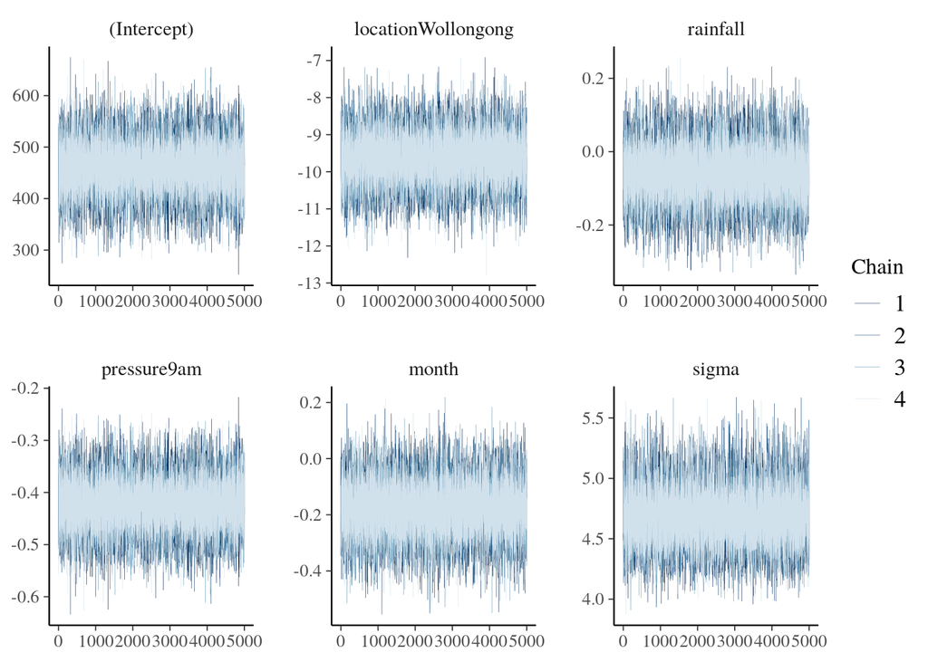

```r
# Trace plots of parallel chains
mcmc_trace(weather_model, size = .1)
```

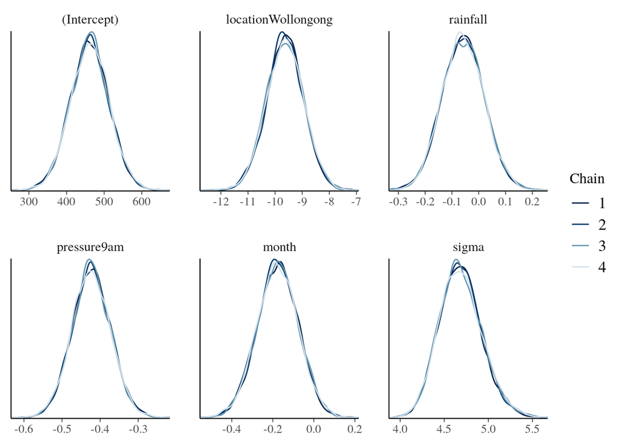

```r
# Density plots of parallel chains
mcmc_dens_overlay(weather_model)
```